*Régression Logistique*

*Pourquoi la régression logistique ?*

La **régression logistique** est l’un des algorithmes d’apprentissage automatique les plus couramment utilisés en matière de classification **binaire** et lorsque nous appliquons un kernel de type linéaire à notre SVM, ces deux dernières méthodes **se rapprochent**. En Statistiques, nous devons constamment faire face à un **trade-off** entre *pouvoir prédicitf* et *interprétabilité* des résultats. Le principal avantage de la régression logistique comparée au SVM est alors sa force d’interprétabilité. C’est ainsi qu’on décide de l’utiliser comme premier **benchmark**. Nous gardons ici le même rééchantillonnage que pour le SVM.

*Résultats*

Pour la sélection de nos variables, nous choisissons la sélection automatique **‘forward’** avec la fonction **‘stepAIC’**. Tout d’abord, avec la fonction *glm*, nous avons régressé la variable Class sur les variables selectionnées grâce à la méthode de sélection forward. Rappel de la séléction forward :

Au départ, notre modèle contient seulement la constante. La sélection forward va alors choisir de faire rentrer une variable dans notre modèle. Pour faire ce choix, un test du Langrange Multiplier est fait. La variable choisi est alors celle dont la p-value est inférieure à un seuil que l’on fixe. Ce processus s’arrête lorsque ce seuil devient inférieur à la p-value. Toute variable qui entre dans le modèle ne peut en sortir. On obtient alors le modèle suivant :

```
##
## Call:
## glm(formula = Class ~ V14 + V4 + V12 + V10 + V13 + V8 + V6 +
##     V11 + V26 + V16 + V17 + V9 + V1 + V27 + V28 + V18 + V2 +
##     V23 + V22 + V21 + V5 + Time + V19, family = binomial(logit),
##     data = train)
##
## Deviance Residuals:
##     Min       1Q   Median       3Q      Max
## -3.4065   0.0000   0.1004   0.2150   4.0406
##
## Coefficients:
##               Estimate Std. Error z value Pr(>|z|)
## (Intercept)  4.038e+00  2.035e-01  19.843  < 2e-16 ***
## V14          1.867e+00  1.816e-01  10.282  < 2e-16 ***
## V4          -1.098e+00  7.675e-02 -14.311  < 2e-16 ***
## V12          1.666e+00  1.722e-01   9.672  < 2e-16 ***
## V10          1.341e+00  1.612e-01   8.320  < 2e-16 ***
## V13          4.242e-01  6.732e-02   6.301 2.96e-10 ***
## V8           7.309e-01  8.299e-02   8.807  < 2e-16 ***
## V6           2.403e-01  7.259e-02   3.310 0.000932 ***
## V11         -7.982e-01  1.183e-01  -6.745 1.53e-11 ***
## V26          5.907e-01  1.803e-01   3.277 0.001050 **
## V16          1.013e+00  1.696e-01   5.970 2.38e-09 ***
## V17          1.456e+00  2.628e-01   5.542 3.00e-08 ***
## V9           5.172e-01  9.874e-02   5.237 1.63e-07 ***
## V1          -4.694e-01  8.610e-02  -5.451 5.00e-08 ***
## V27         -1.094e+00  2.476e-01  -4.419 9.92e-06 ***
## V28         -9.536e-01  2.863e-01  -3.331 0.000865 ***
## V18          5.434e-01  1.396e-01   3.892 9.93e-05 ***
## V2           3.044e-01  6.355e-02   4.790 1.66e-06 ***
## V23          1.890e-01  7.127e-02   2.652 0.008000 **
## V22         -3.933e-01  1.148e-01  -3.425 0.000615 ***
## V21         -2.903e-01  8.323e-02  -3.488 0.000487 ***
## V5          -2.009e-01  6.617e-02  -3.035 0.002404 **
## Time         5.201e-06  1.857e-06   2.801 0.005090 **
## V19         -1.414e-01  9.316e-02  -1.518 0.128949
## ---
## Signif. codes:  0 '***' 0.001 '**' 0.01 '*' 0.05 '.' 0.1 ' ' 1
##
## (Dispersion parameter for binomial family taken to be 1)
##
##     Null deviance: 9436.6  on 7575  degrees of freedom
## Residual deviance: 1573.4  on 7552  degrees of freedom
## AIC: 1621.4
##
## Number of Fisher Scoring iterations: 13
```

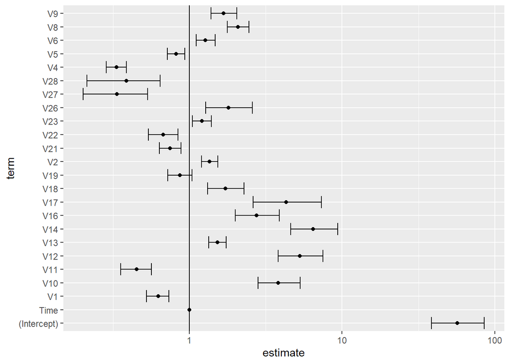

Nous remarquons que le terme de « deviance » est employé deux fois dans la sortie. La déviance est une mesure de qualité de l’ajustement d’un modèle linéaire généralisé. Cette sortie nous signale deux formes de déviance : la déviance **nulle** et la déviance **résiduelle**.

Que signifie la déviance du modèle nul (Null deviance) ? Le modèle nul est caractérisé par aucun effet du facteur, donc p = constante. (L’estimation du maximum de vraisemblance de la probabilité se fait par la fréquence).

Une ligne précise la valeur de l’AIC : le critère d’information d’Akaike, qui permet de mesurer la qualité de notre modèle en comparaison avec d’autres modèles. Le modèle avec l’AIC le plus faible est alors choisi.

Enfin nous avons le nombre d’itérations de l’algorithme de Fisher qui est égale à **13**. Cela signifie que l’algorithme de scoring de Fisher à eu besoin de **13** itérations pour effectuer l’ajustement du modèle.

*Matrice de confusion*

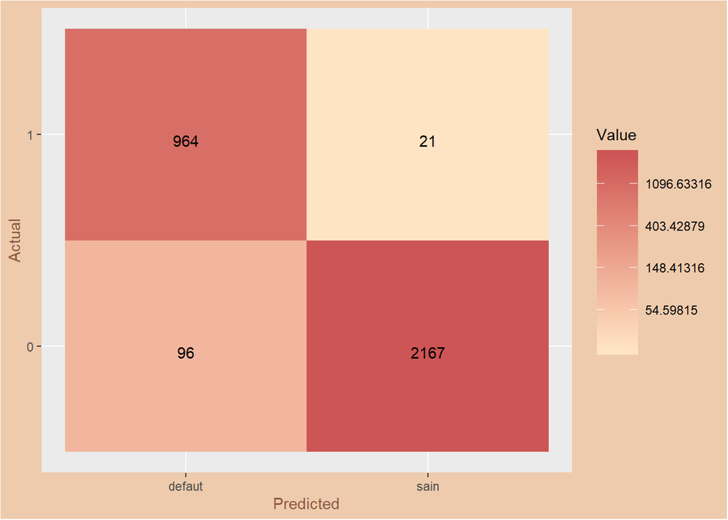

Comme pour le SVM, la matrice de confusion va nous fournir des informations sur les erreurs de classification de la régression logistique. Nous avons ici un taux d’erreur de classification de **3.602%** et donc **96.398%** de transactions correctement classées. Le taux d’exatitude des transactions correctement classées ici est inferieur à celui trouvé pour le SVM, mais cette différence n’est pas flagrante.

*Courbe ROC*

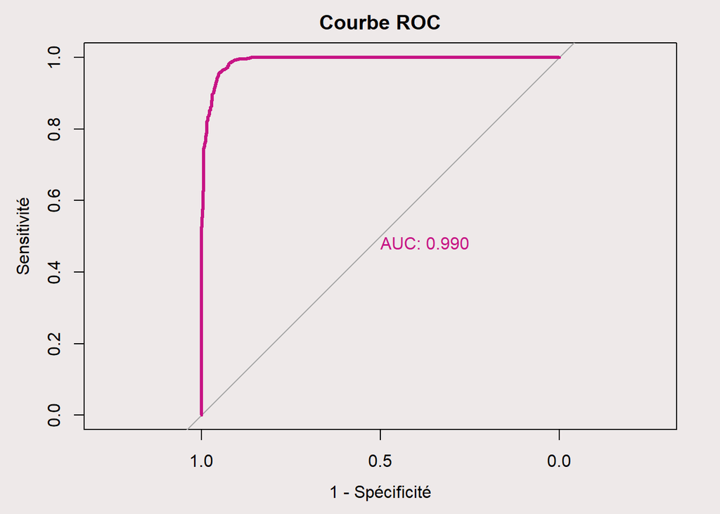

*Courbe PR*

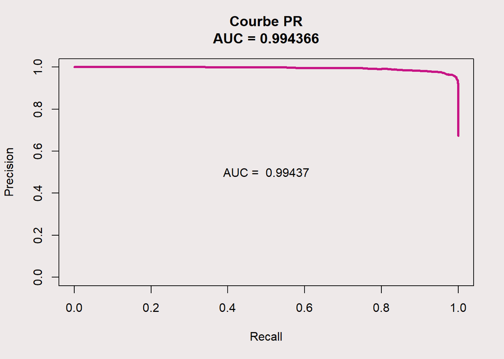

Concerant la courbe precision-recall, nous avons une aire sous la courbe à hauteur de **0.994**.